# Modeling Sales Win Rates based on historical CRM data

# Install dependencies

Fixes issues with Lambda Labs instances. LambdaLabs uses an older version of JupyterLab, v4.0.9. Current is 4.2.1. Must upgrade all of these packages on Lambda Labs, otherwise it will cause errors

```python
%pip install --upgrade --quiet pip xgboost bottleneck pandas scikit-learn scipy numpy matplotlib pyarrow seaborn numexpr jupyterlab jupyter ipykernel jupyter-server ydata-profiling anaconda-cloud-auth
print('\n\n========== Finished installing/upgrading PIP packages==========')
```

# Load dependencies

```python
# Disable certain Lint checks that don't apply to Jupyter Notebooks, or that
# I just don't care about.
# pylint: disable=pointless-statement
# pylint: disable=fixme
# pylint: disable=expression-not-assigned
# pylint: disable=missing-module-docstring
# pylint: disable=invalid-name
# pylint: disable=import-error
# pylint: disable=line-too-long

import os
import importlib
import time
# import multiprocessing

import pandas as pd
import matplotlib.pyplot as plt
# import numpy as np
# import seaborn as sns

from xgboost import XGBClassifier
from sklearn.model_selection import GridSearchCV, train_test_split
from sklearn.metrics import confusion_matrix, ConfusionMatrixDisplay, accuracy_score, make_scorer, recall_score, average_precision_score, balanced_accuracy_score, f1_score, precision_score, log_loss

# My custom python module(s)
import saleslib             # my custom Python module for this project
importlib.reload(saleslib)  # force reload because I'm frequently making updates

# Module configuration
# sns.set_theme(style="darkgrid")    # causes minor issues with Confusion Matrix
pd.options.display.max_rows    = 100    # display more for debugging
pd.options.display.max_columns = 100    # display more for debugging
```

# GPU support

TODO: GPU is currently running 10x slower than CPU on LambdaLabs, need to investigate further

```python
# %pip install --upgrade pip setuptools conda requests_mock clyent==1.2.1
# %pip install cupy-cuda12x
# !python3 -m cupyx.tools.install_library --cuda 11.x --library cutensor
# %pip freeze | grep cupy
# import cupy
```

# Setting custom parameters for this notebook

```python
# path to training data that was prepared by a separate notebook.
filename = os.path.join(
   os.getcwd(), "data", "raw_CRM_opps_export-dummydata_prepped.csv"
)

# percentage of training data to use for test
TEST_SIZE = 0.3

# random seed
from saleslib import RANDOM_STATE
import random
# TODO: investigate seeding in any other PRNG engines used, ensure consistency
random.seed(RANDOM_STATE)

# Number of cross validation folds
NUM_CV_FOLDS = 5

# the name for the column that indicates the label/target
# the training CSV file should have headers
LABEL_COLUMN_NAME = "Won"

# Which metric from the list below is used for optimizing in GridSearchCV
METRIC_TO_OPTIMIZE = "Recall"

# list of metrics to compute for each model in the GridSearch
# https://scikit-learn.org/stable/modules/model_evaluation.html#scoring-parameter
scoring = {"Recall":             make_scorer(recall_score),
           "AUC":                "roc_auc",                               # Compute Area Under the Receiver Operating Characteristic Curve (ROC AUC) from prediction scores.
           "Accuracy":           make_scorer(accuracy_score),             #

           "F1":                 make_scorer(f1_score),                   # harmonic mean of the precision and recall, The relative contribution of precision and recall to the F1 score are equal.
           "Balanced Accuracy":  make_scorer(balanced_accuracy_score),    # the average of recall obtained on each class
           "Precision":          make_scorer(precision_score),            # The ability of the classifier not to label as positive a sample that is negative; Precision of the positive class in binary classification or weighted average of the precision of each class for the multiclass task.
           "Avg Precision":      make_scorer(average_precision_score),     # summarizes a precision-recall curve as the weighted mean of precisions achieved at each threshold, with the increase in recall from the previous threshold used as the weight
           #"neg_log_loss":       "neg_log_loss",
           }
```

# Load, validate, split up the training data

Check that the data does not contain any missing values and all values are numeric datatypes.

```python
df = pd.read_csv(filename, header=0)
saleslib.verify_data_ready_for_training(df)
y = df[LABEL_COLUMN_NAME]
X = df.drop(columns=LABEL_COLUMN_NAME, axis=1)

# save memory since this variable takes up a lot of space and isn't used again
del df

X_train, X_test, y_train, y_test = train_test_split(
    X, y, test_size=TEST_SIZE, random_state=RANDOM_STATE,
    #stratify=y      # force stratification across target column
)
```

# Define the search grid and run it

https://xgboost.readthedocs.io/en/latest/python/python_api.html

https://xgboost.readthedocs.io/en/latest/treemethod.html

https://xgboost.readthedocs.io/en/stable/parameter.html

```python
generic_model = XGBClassifier(
    objective='binary:logistic',
    random_state=RANDOM_STATE,
    # booster='',        # options: gbtree (default, tree functions), gblinear (linear functions), dart (tree with dropouts)
    # tree_method='',    # options: hist (default, also called auto), approx, exact (super slow)
    # n_jobs=1,
    # device='cuda'      # force GPU usage instead of CPU
    )

# basic but broad search for major changes
# param_grid = {
#     "max_depth":     [2, 3, 4],
#     "n_estimators":  [100, 1000, 3200],
#     "learning_rate": [0.1, 0.5, 0.85]
#     }

# short test runs, just the optimal model
# param_grid = {
#     "max_depth":     [2],
#     "n_estimators":  [3200],
#     "learning_rate": [0.85]
#     }

# short test runs, just the optimal model
param_grid = {
    "max_depth":     [2],
    "n_estimators":  [3200],
    "learning_rate": [0.85]
    }

# for pretty charts:
# param_grid = {
#     "max_depth":     [2], #[2, 4, 8],
#     "n_estimators":  [50, 100, 250, 500, 750, 1000, 1500, 1750, 2000, 2250,
#                       2500, 2750, 3000, 3500, 4000, 4500, 5000, 10000, 20000,
#                       40000],
#     "learning_rate": [0.85], #[0.01, 0.05, 0.1, 0.25, 0.35, 0.45, 0.55, 0.60, 0.65,
#                      # 0.75, 0.8, 0.9]
#     }

# create the grid search object
clf = GridSearchCV(
    generic_model,
    param_grid=param_grid,
    verbose=1,
    n_jobs=-1,                      # use all available CPU cores
    cv=NUM_CV_FOLDS,
    scoring=scoring,                # list of all metrics to compute
    refit=METRIC_TO_OPTIMIZE,       # list of metric to optimize
    return_train_score=True         # used in charts below
)

gridsearch_time_start = time.time() # start a timer for the grid search
# clf.fit(cupy.array(X), y)         # GPU version
clf.fit(X, y)                       # CPU version
gridsearch_time_stop = time.time()  # end the timer
gridsearch_time_total = gridsearch_time_stop - gridsearch_time_start

# Lambda Labs doesn't stream subprocesses to Jupyter Notebooks, so it is
# hard to see progress or know when it's done, even with verbose=4
#print('\n===================== FIT FINISHED ===============================\n')

#.cv_results_ does not offer training times on specific models or on the grid
# search as a whole.
print(f'* Total Grid Search time: {gridsearch_time_total:.0f} sec')
```

[output not shown]

# Display results of hyperparmater search

```python
bst = saleslib.train_and_evaluate_optimal_model_from_gridsearch(clf,
                                        METRIC_TO_OPTIMIZE, X_train, y_train)
```

# Visualizing model performance for each hyperparameter

## Chart - Performance vs hyperparameter n_estimators

[figure not shown]

```python
saleslib.plot_grid_search_scores('n_estimators', clf, scoring)  #, scale='log'
```

## Chart - Performance vs hyperparameter max_depth

[figure not shown]

```python
saleslib.plot_grid_search_scores('max_depth', clf, scoring)
```

## Chart - Performance vs hyperparameter learning_rate

[figure not shown]

```python
saleslib.plot_grid_search_scores('learning_rate', clf, scoring)
```

# Confusion Matrix

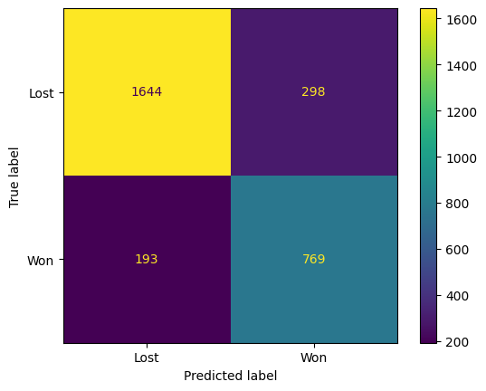

```python
preds = bst.predict(X_test)
cm    = confusion_matrix(y_test, preds, labels=bst.classes_)

disp  = ConfusionMatrixDisplay(confusion_matrix=cm,
                              display_labels=['Lost', 'Won'])

disp.plot()

# another option for displaying with different color gradients
# ConfusionMatrixDisplay.from_estimator(clf, X_test, y_test, cmap='Greens')

plt.show()
```